# Bayesian data analysis & cognitive modeling

\[ \definecolor{firebrick}{RGB}{178,34,34} \newcommand{\red}[1]{{\color{firebrick}{#1}}} \] \[ \definecolor{mygray}{RGB}{178,34,34} \newcommand{\mygray}[1]{{\color{mygray}{#1}}} \] \[ \newcommand{\set}[1]{\{#1\}} \] \[ \newcommand{\tuple}[1]{\langle#1\rangle} \] \[\newcommand{\States}{{T}}\] \[\newcommand{\state}{{t}}\] \[\newcommand{\pow}[1]{{\mathcal{P}(#1)}}\]

## overview

- Metropolis Hastings (recap)
- Hamiltonian Monte Carlo
- Stan

## Metropolis Hastings

## island hopping

[figure not shown]

- set of islands \(X = \{x_1, x_2, \dots x_n\}\)
- goal: hop around & visit every island \(x_i\) proportional to its population \(P(x_i)\)
  - think: "samples" from \(X \sim P\)
- problem: island hopper can remember at most 2 islands' population
  - think: we don't know the normalizing constant

## Metropolis Hastings

- let \(f(x) = \alpha P(x)\) (e.g., unnormalized posterior)
- start at random \(x^0\), define probability \(P_\text{trans}(x^i \rightarrow x^{i+1})\) of going from \(x^{i}\) to \(x^{i+1}\)
  - proposal \(P_\text{prpsl}(x^{i+1} \mid x^i)\): prob. of considering jump to \(x^{i+1}\) from \(x^{i}\)
  - acceptance \(P_\text{accpt}(x^{i+1} \mid x^i)\): prob of making jump when \(x^{i+1}\) is proposed \[P_\text{accpt}(x^{i+1} \mid x^i) = \text{min} \left (1, \frac{f(x^{i+1})}{f(x^{i})} \frac{P_\text{prpsl}(x^{i} \mid x^{i+1})}{P_\text{prpsl}(x^{i+1} \mid x^i)} \right)\]
  - transition \(P_\text{trans}(x^i \rightarrow x^{i+1}) = P_\text{prpsl}(x^{i+1} \mid x^i) \times P_\text{accpt}(x^{i+1} \mid x^i)\)

## influence of proposal distribution

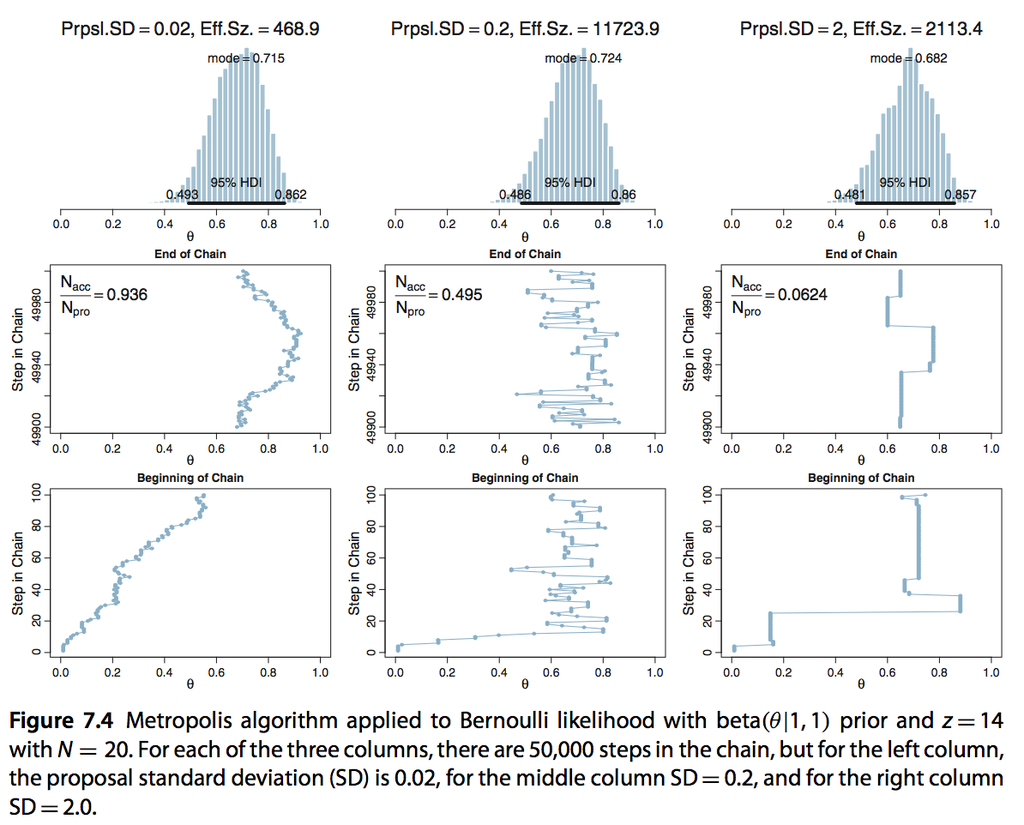

## Hamiltonian MC

## Hamiltonian motion

- Hamiltonian movement
  - reformulates classical mechanics
  - precursor of statistical physics
  - closed system differential equations
  - potential vs. kinetic energy

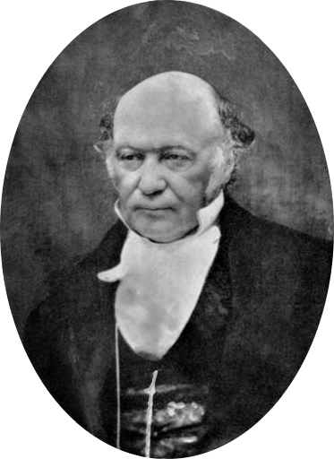

potential

[figure not shown]

kinetic

[figure not shown]

## example 1

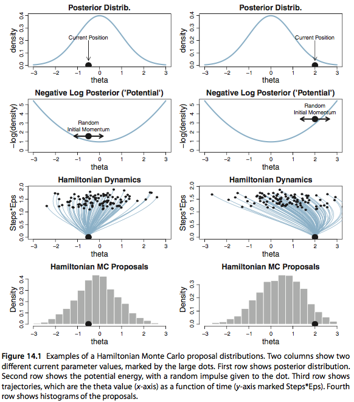

## tuning parameters

- momentum
  - e.g., standard deviation of Gaussian that determines initial jiggle

- step size
  - how big a step to take in discretization of gradient

- number of steps
  - how many steps before producing the proposal

## example 2

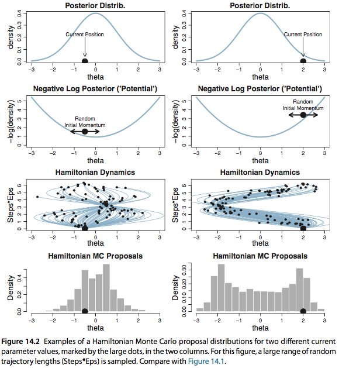

## example 3

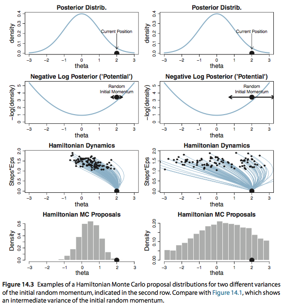

## Stan

## overview

- [mc-stan.org](http://mc-stan.org/)
- actively developed by Andrew Gelman, Bob Carpenter and others
- uses HMC and NUTS, but can do variational Bayes and MAPs too
- written in C++
- cross-platform
- interfaces: command line, Python, Julia, R, Matlab, Stata, Mathematica
- many additional packages/goodies

[figure not shown]

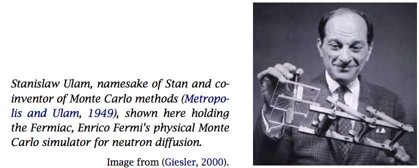

## example: JAGS vs. Stan

```r
require('rjags')
ms = "
model{
  theta ~ dbeta(1,1)
  k ~ dbinom(theta, N)
}"
# prepare data for JAGS
dataList = list(k = 14, N = 20)
# set up and run model
jagsModel = jags.model(
  file = textConnection(ms),
  data = dataList, n.chains = 2)
update(jagsModel, n.iter = 5000)
codaSamples = coda.samples(
  jagsModel,
  variable.names = c("theta"),
  n.iter = 5000)
```

```r
require('rstan')
ms = "
data {
  int<lower=0> N ;
  int<lower=0> k ;
}
parameters {
  real<lower=0,upper=1> theta ;
}
model {
  theta ~ beta(1,1) ;
  k ~ binomial(N, theta) ;
}"
# prepare data for Stan
dataList = list(k = 14, N = 20)
# set up and run
mDso = stan_model(model_code = ms)
stanFit = sampling(object = mDso,
  data = dataList,
  chains = 2,
  iter = 10000,
  warmup = 5000)
```

## compare output

JAGS

```r
coda::effectiveSize(codaSamples)
```

```
##   theta
## 10063.5
```

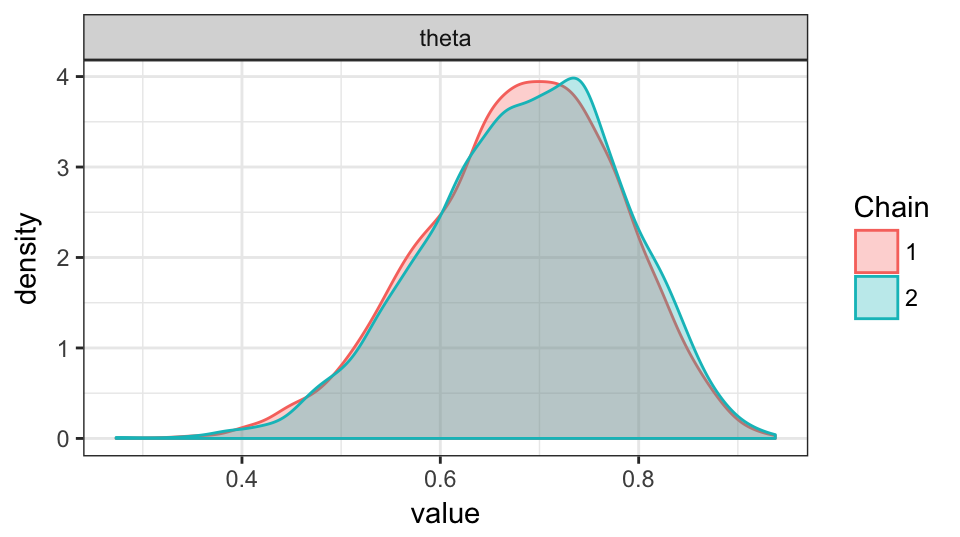

```r
ms = ggs(codaSamples)
ggs_density(ms)
```

Stan

```r
coda::effectiveSize(As.mcmc.list(stanFit))[1]
```

```
##    theta
## 3858.451
```

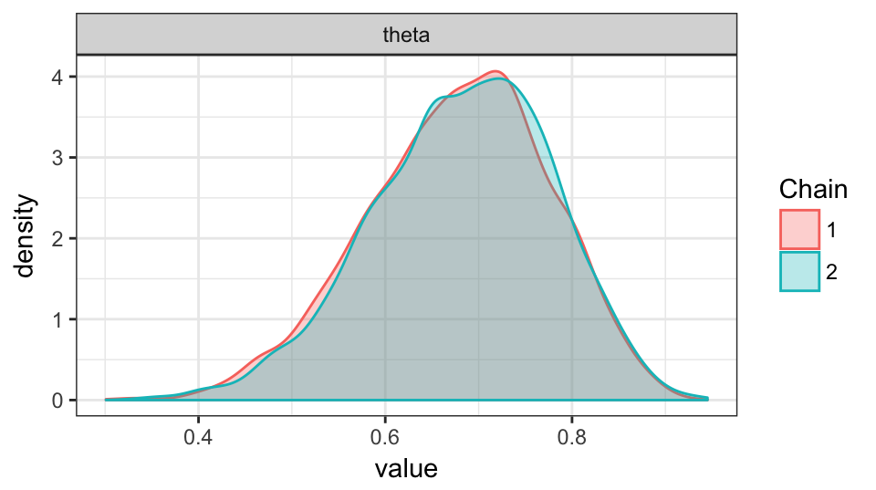

```r
ms = ggs(stanFit)
ggs_density(ms)
```

## Stan output

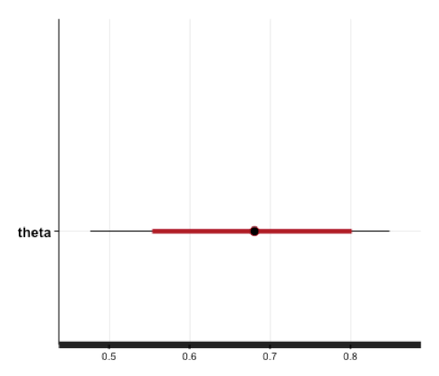

```r
plot(stanFit)
```

```r
print(stanFit, digits_summary = 1)
```

```
## Inference for Stan model: 23b975ca8e7a249bab8c58ed69033d00.
## 2 chains, each with iter=10000; warmup=5000; thin=1;
## post-warmup draws per chain=5000, total post-warmup draws=10000.
##
##        mean se_mean  sd  2.5%   25%   50%   75% 97.5% n_eff Rhat
## theta   0.7       0 0.1   0.5   0.6   0.7   0.7   0.9  3648    1
## lp__  -14.3       0 0.7 -16.2 -14.4 -14.0 -13.8 -13.8  3781    1
##
## Samples were drawn using NUTS(diag_e) at Tue Jul  4 16:08:16 2017.
## For each parameter, n_eff is a crude measure of effective sample size,
## and Rhat is the potential scale reduction factor on split chains (at
## convergence, Rhat=1).
```

## `bayesplot` package

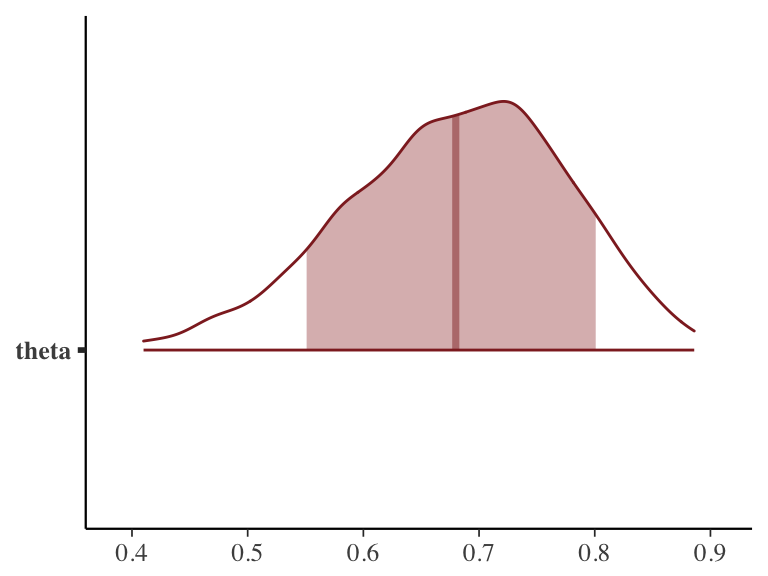

```r
require(bayesplot)
posterior <- as.array(stanFit)
color_scheme_set("red")
mcmc_areas(
  posterior,
  pars = c("theta"),
  prob = 0.8, # 80% intervals
  prob_outer = 0.99, # 99%
  point_est = "mean"
)
```

more on the `bayesplot` package: [here](https://cran.r-project.org/web/packages/bayesplot/index.html)

## discrete latent parameters

## discrete latent parameters

problem

Stan needs gradients / derivatives

- cannot infer discrete latent parameters

(sometimes) possible solution

marginalize out

## Exam scores

15 people answered 40 exam questions. Here's their scores:

```r
k <- c(21,17,21,18,22,31,31,34,
       34,35,35,36,39,36,35)
p <- length(k) #number of people
n <- 40 # number of questions
```

- assume that some guessed randomly, others gave informed answers
- who is a guesser?
- what's the probability of correct answering for non-guessers?

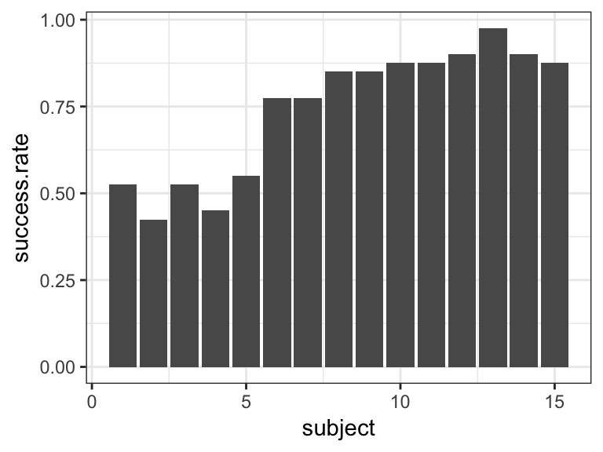

Lee & Wagenmakers, Chapter 6.1

## JAGS model

```r
k <- c(21,17,21,18,22,31,31,34,
       34,35,35,36,39,36,35)
p <- length(k) #number of people
n <- 40 # number of questions
```

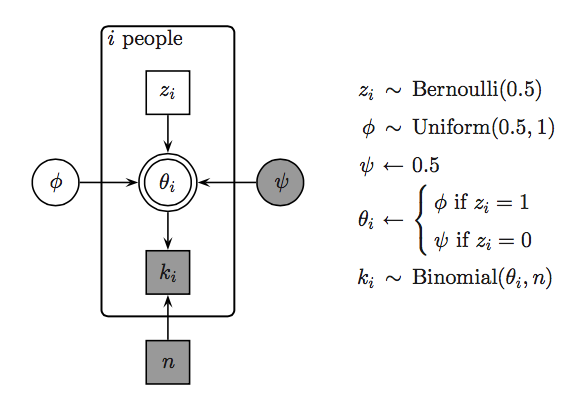

```r
model{
  for (i in 1:p){
    z[i] ~ dbern(0.5)
  }
  psi = 0.5
  phi ~ dunif(0.5,1)
  for (i in 1:p){
    theta[i] = ifelse(z[i]==0,psi,phi)
    k[i] ~ dbin(theta[i],n)
  }
}
```

## JAGS model: results

```r
k <- c(21,17,21,18,22,31,31,34,34,35,35,36,39,36,35)
show(summary(codaSamples)[[1]][,1:2])
```

```
##            Mean         SD
## phi   0.8632095 0.01716929
## z[1]  0.0000000 0.00000000
## z[2]  0.0000000 0.00000000
## z[3]  0.0000000 0.00000000
## z[4]  0.0000000 0.00000000
## z[5]  0.0000000 0.00000000
## z[6]  0.9952000 0.06911901
## z[7]  0.9938000 0.07849953
## z[8]  1.0000000 0.00000000
## z[9]  1.0000000 0.00000000
## z[10] 1.0000000 0.00000000
## z[11] 1.0000000 0.00000000
## z[12] 1.0000000 0.00000000
## z[13] 1.0000000 0.00000000
## z[14] 1.0000000 0.00000000
## z[15] 1.0000000 0.00000000
```

## model: JAGS vs Stan

```r
model{
  for (i in 1:p){
    z[i] ~ dbern(0.5)
  }
  psi = 0.5
  phi ~ dunif(0.5,1)
  for (i in 1:p){
    theta[i] = ifelse(z[i]==0,
                      psi,phi)
    k[i] ~ dbin(theta[i],n)
  }
}
```

JAGS \(\uparrow\)

Stan \(\rightarrow\)

```c
data {
  int<lower=1> p;  int<lower=0> k[p];   int<lower=1> n;
}
transformed data {
  real psi; psi <- .5;
}
parameters {
  real<lower=.5,upper=1> phi;
}
transformed parameters {
  vector[2] log_alpha[p];
  for (i in 1:p) {
    log_alpha[i,1] <- log(.5) + binomial_log(k[i], n, phi);
    log_alpha[i,2] <- log(.5) + binomial_log(k[i], n, psi);
  }
}
model {
  for (i in 1:p)
    increment_log_prob(log_sum_exp(log_alpha[i]));
}
generated quantities {
  int<lower=0,upper=1> z[p];
  for (i in 1:p) {
    z[i] <- bernoulli_rng(softmax(log_alpha[i])[1]);
  }
}
```

## log-scores & marginalizing out

log score

- \(\log P(D, \theta) = \log \left( P(\theta) \ P(D \mid \theta) \right ) = \log P(\theta) + \log P(D \mid \theta)\)
- log-score for one participant in our example:

\[\log P(k_i, n, z_i, \phi) = \log \text{Bern}(z_i \mid 0.5) + \log \text{Binom}(k_i, n, \text{ifelse}(z=1, \phi, 0.5))\]

marginalizing out

\[ \begin{align*} P(k_i, n, \phi) & = \sum_{z_i \in \set{0,1}} \text{Bern}(z_i \mid 0.5) \ \text{Binom}(k_i, n, \text{ifelse}(z=1, \phi, 0.5)) \\ & = \text{Bern}(0 \mid 0.5) \ \text{Binom}(k_i, n, 0.5)) + \\ & \ \ \ \ \ \ \ \ \ \ \text{Bern}(1 \mid 0.5) \ \text{Binom}(k_i, n, \phi)) \\ & = \underbrace{0.5 \ \text{Binom}(k_i, n, 0.5))}_{\alpha_0} + \underbrace{0.5 \ \text{Binom}(k_i, n, \phi))}_{\alpha_1} \\ \log P(k_i, n, \phi) & = \log \sum_{i=0}^1 \exp \log \alpha_i \end{align*}\]

## Stan model: results

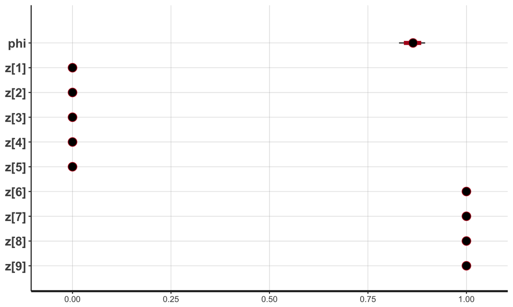

## added goodies

## variational Bayes

idea

approximate posterior distribution by a well-behaved function

concretely

find parametric function \(F(\theta \mid \phi)\) and look for best-fitting parameters:

\[\phi^* = \arg\min_{\phi} \text{KL}(F(\theta \mid \phi) \ \ || \ \ P(\theta \mid D) ) \]

where KL is the Kullback-Leibler divergence:

\[ \text{KL}(P || Q) = \int P(x) \log \frac{P(x)}{Q(x)} \ \text{d}x \]

## maximum a posteriori (MAP)

the MAP is the most likely parameter vector under the posterior distribution:

\[ \theta^* = \arg\max_{\theta} P(\theta \mid D) \]

for flat (possibly improper) priors the MAP is the MLE

## summary

## comparison

|  | JAGS | Stan |
| --- | --- | --- |
| syntax-style | BUGS, R | C++, R, BUGS |
| sampler | MH, Gibbs | Hamiltonian |
| paradigm | declarative | procedural |
| precompilation | no | yes |
| latent discrete variables | yes | hard (or impossible) |
| added goodies | DIC | variational Bayes, MAP, improper priors, rstanarm, loo, … |

## outlook

Friday

- bootcamping with a cognitive model in Stan

Tuesday

- generalized linear model